# ETC1010: Introduction to Data Analysis

Your name

## Instructions to Students

**This is an individual assignment and you must work on it on your own. Collaboration on the assignment constitute collusion. For more on collusion and misconduct please see this [webpage.](https://connect.monash.edu/s/article/FAQ-2144)**

This assignment is designed to simulate a scenario in which you are taking over someone’s existing work and continuing with it to draw some further insights. Therefore you are given an R project inside the Rstudio Cloud Assignment space for ETC1010-5510. You can access that space in this [link](https://rstudio.cloud/spaces/225853/join?access_code=jlyrobmtvVdomco7rv9jvCvCyfcBfRgR_nDhD_V1).

This is a real world data set published by the [SIPRI Military Expenditure Database](https://www.sipri.org/databases/milex). Specifically, the data file called “military-expenditure.csv” is located in your data folder inside the RStudio project, and it will be used for this assignment. This file contains the yearly military expenditure for a number of countries, the world and for different continents too.

You have just joined a consulting company as a data analyst. To get you started on a new project that tries to understand the differences in military expenditure across different countries, you are performing a quick summary of the data while answering a number questions that the chief business analytics leader has asked you to do. This is not a formal report, but rather something you are giving to your manager that describes the data with some interesting insights.

Please make sure you read the hints throughout the assignment to help guide you on the tasks.

The points allocated for each of the elements in the assignment are marked in the questions and next to the code for those questions where a code scaffolding is provided.

## Marking + Grades

This assignment will be worth **10%** of your total grade. **Due on: Monday 28 March 4:30pm (Melbourne time)**. **Late submissions will not be accepted.**

For this assignment, you will need to upload the following into Moodle:

- The rendered html file saved as a pdf. The assignment will be only marked if the pdf is uploaded in Moodle. **The submitted assignment pdf file must have all the code and output visible.**
- To complete the assignment, you will need to fill in the blanks with appropriate R code for some questions. These sections are marked with `___`. For other questions, you will need to write the entire R code chunk.
- **At a minimum, your assignment should be able to be “knitted”** using the `Knit` button for your Rmarkdown document so that you can produce a html file that you will save as pdf file and upload it into Moodle. You will be reminded about how to save the rendered html file into pdf in the tutorials of Week 3.

If you want to look at what the assignment looks like as you progress , remember that you can set the R chunk options to `eval = FALSE` like so to ensure that you can knit the file:

````markdown
```{r this-chunk-will-not-run, eval = FALSE} `r''`
a <- 1 + 2
```
````

**If you use `eval = FALSE` or `echo = FALSE`, please remember to ensure that you have set to `eval = TRUE` and `echo = TRUE` when you submit the assignment, to ensure all your R codes run.**

**IMPORTANT: You must use R code to answer all the questions in the report.**

## Due Date

This assignment is due in by close of business (4:30pm) on Monday, 28 March 2022. You will submit the knitted html file **saved as a pdf** via Moodle. Please make sure you add your name on the YAML part of the Rmd file before you knit it and save it as pdf.

## How to find help from R functions?

Remember, you can look up the help file for functions by typing: `?function_name`. For example, `?mean`.

## Load all the libraries that you need here

```r
library(tidyverse)
```

## Reading and preparing data

```r
expenditure <- read_csv("Data/military-expenditure.csv")
```

```r
tail(expenditure, 6)
```

```
## # A tibble: 6 × 4
##   Entity   Code   Year military_expenditure
##   <chr>    <chr> <dbl>                <dbl>
## 1 Zimbabwe ZWE    2014           1033292790
## 2 Zimbabwe ZWE    2015           1083475614
## 3 Zimbabwe ZWE    2016           1046329810
## 4 Zimbabwe ZWE    2017            986095198
## 5 Zimbabwe ZWE    2018           1100563838
## 6 Zimbabwe ZWE    2019            546939000
```

## Question 2: How many observations and variables does the data set *expenditure* have (1pt)? Use inline code to complete the sentence below (2pts)

```r
dim(expenditure)
```

```
## [1] 8278    4
```

The number of observations are `8278` and the number of variables are `4`

## Question 3: What is the name of the 4th variable in this data set (2pts)? Use R commands to answer this question.

```r
colnames(expenditure)[4]
```

```
## [1] "military_expenditure"
```

## Question 4: Using the *expenditure* data set, rename the variable of “Entity” to “Country” and save this new data frame in a data object called *tab_aus* (2pts). Display the first 4 rows corresponding to the country “Australia” for all the variables in *tab_aus* (1pt).

```r
tab_aus<- expenditure  %>% # Complete the rest of the code lines
  rename(Country = Entity) %>%
  subset(Country == "Australia")

head(tab_aus,4)
```

```
## # A tibble: 4 × 4
##   Country   Code   Year military_expenditure
##   <chr>     <chr> <dbl>                <dbl>
## 1 Australia AUS    1950           2793226922
## 2 Australia AUS    1951           4012038067
## 3 Australia AUS    1952           5124027521
## 4 Australia AUS    1953           5157550597
```

## Question 5: How many years are recorded in the *expenditure* data frame for “Australia” (2pts)?

```r
length(unique(expenditure$Year))
```

```
## [1] 72
```

## Question 6: Using the data frame *expenditure*, rename the variable Entity to Country. Then select the observations corresponding to the following countries: Ukraine, Russia, World, Europe, Australia and United States and store this data in a new data object called *data_tab* (3pts). Print the first 4 rows of the *data_tab* data set (1pt). What is the dimension of the new data set data_tab? (2pts)

```r
data_tab <- expenditure %>%
  rename(Country = Entity) %>%         # Complete the rest of the code lines

filter(Country %in% c("Ukraine","Russia","World","Europe",  "Australia", "United States")) # Complete the rest of the code lines

dim(data_tab)
```

```
## [1] 347   4
```

The dimension of data_tab is *347* rows and *4* columns

## Question 7: How many years are recorded for each of the countries in *data_tab* (1pt). Display the results using functions from the tidyverse package. **Hint:**This is equivalent to displying the number of observations for each of the countries.

```r
data_tab %>% group_by(Country) %>%
  summarise(Years= length(unique(Year)))
```

```
## # A tibble: 6 × 2
##   Country       Years
##   <chr>         <int>
## 1 Australia        71
## 2 Europe           72
## 3 Russia           32
## 4 Ukraine          28
## 5 United States    72
## 6 World            72
```

## Question 8: What are the unique elements in the variable *Country* in the data object *data_tab* (Display the results using R code) (1pt)? How many are there (use an R command to count the number of elements) and complete the sentence below using inline R code (1pt).

> Remember that you can learn more about what these functions by typing: `?unique` or `?length` into the R console.

There is 6 different elements in the variable Country inside the data object called *data_tab*.

## Question 9: Using the *data_tab* data frame, calculate the total sum of the variable *military_expenditure* for each of the countries in the data set selecting only the years from 1994. Store the results in a new variable called *Total*. (2pts). Make sure you store the new data frame in a data object called *Total_expenditure* and display the results (#1pt). **Hint:** This new data object will need to have two columns.

```r
Total_expenditure <- data_tab %>%
  filter(military_expenditure>= 1994) %>%
  group_by(Country) %>%
  summarise(Total= sum(military_expenditure))
```

## Question 10: What is the proportion of the *Total_expenditure* of each of the countries you stored in the object *Total_expenditure* (in question 9) with respect of the world? To answer this question, please create a new variable called *Percentage* and store the new data frame under the data object *Percen_expenditure*. Display the resulting data frame (this data frame must contain the variables *Country*, *Total* and *Percentage*) (2pts) **Hint:** You can calculate the percentage by dividing the Total expenditure of each country by the total world expenditure and multiply by 100.

```r
Percen_expenditure <- Total_expenditure %>%
 mutate(Percentage= Total/sum(Total)*100);Percen_expenditure
```

```
## # A tibble: 6 × 3
##   Country         Total Percentage
##   <chr>           <dbl>      <dbl>
## 1 Australia     8.75e11     0.627
## 2 Europe        1.85e13    13.3
## 3 Russia        2.06e12     1.48
## 4 Ukraine       6.56e10     0.0470
## 5 United States 3.98e13    28.5
## 6 World         7.83e13    56.1
```

## Question 11: If you look at the data *Percen_expenditure*, you will notice that the Country variable is coded as character. Transform the variable of *Country* into a factor variable (**Hint:** Check ?as.factor in your R console). Store the new data object that has the variable *Country* defined as a factor into the same data object called *Percen_expenditure* (1pt).Display all the rows of the data set (1pt)

```r
Percen_expenditure$Country <- as.factor(Percen_expenditure$Country)

Percen_expenditure
```

```
## # A tibble: 6 × 3
##   Country         Total Percentage
##   <fct>           <dbl>      <dbl>
## 1 Australia     8.75e11     0.627
## 2 Europe        1.85e13    13.3
## 3 Russia        2.06e12     1.48
## 4 Ukraine       6.56e10     0.0470
## 5 United States 3.98e13    28.5
## 6 World         7.83e13    56.1
```

## Question 12: Use the data object *Percen_expenditure*, order the observations from larger to smaller according to the *Percentage* variable and display the results in a table (1pt). Without including the results for the *World* entries, which is the country with the largest expenditure (1pt)? And with the lowest (1pt)?

```r
or_percen_expenditure <- Percen_expenditure %>%
  slice(-6) %>%
  arrange(desc(Percentage))
```

The country with the highest expenditure is *United States* and with the lowest is *Ukraine*.

## Question 13: In the data object *Percen_expenditure* extract all the observations for the second row (1pt).

Using the same data object *Percen_expenditure* extract all the observations corresponding to the variable *Total* (1pt).

```r
Percen_expenditure[,2]
```

```
## # A tibble: 6 × 1
##     Total
##     <dbl>
## 1 8.75e11
## 2 1.85e13
## 3 2.06e12
## 4 6.56e10
## 5 3.98e13
## 6 7.83e13
```

## Question 14: Using the *data_tab* data object, display in a graph the trend in militar_expenditure for the World (on the x-axis display the years and on the y-axis the *miliary_expenditure* values for the selected entries) (6pts). **Hint:** You first need to select the data that corresponds to the *World* entries and then create the plot. Trends are displayed with a line graph.

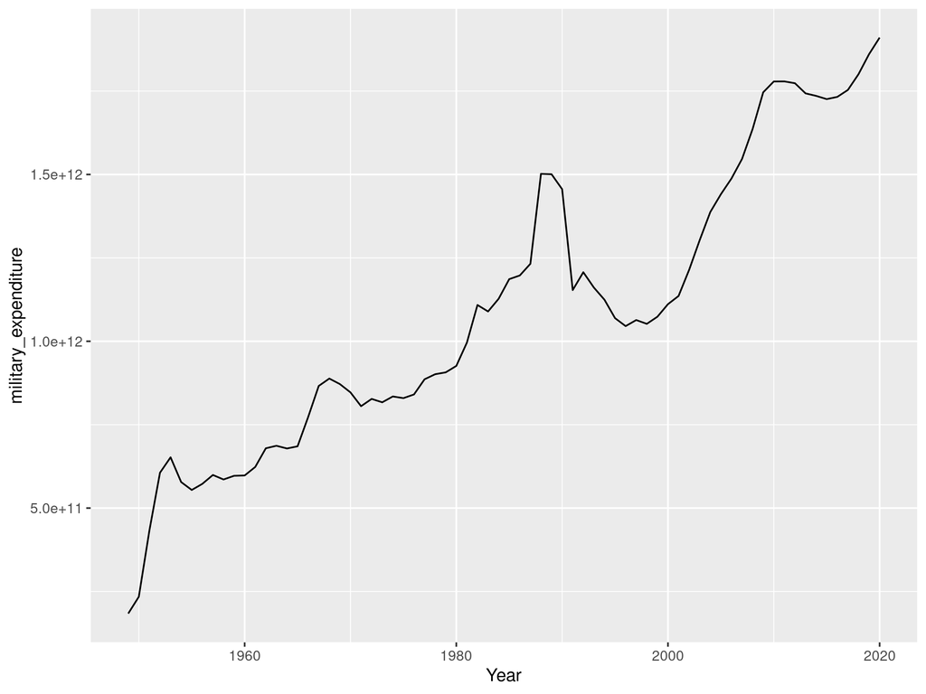

```r
data_world <- data_tab %>%
  filter(Country== "World")    # Complete the rest of the code lines

ggplot(data_world,mapping = aes(x= Year, y= military_expenditure))+
  geom_line()
```